# Données vectorielles

#### Visualiser des données vectorielles par attribut

Lorsque nous avons affiché les métadonnées du *shapefile* `pistes_cyclables`, vous avez peut-être observé que ce dernier comprenait l’attribut `TYPE_VOIE` qui caractérise le type de pistes cyclables de chaque multiligne. Affichons les métadonnées à nouveau:

```r
pistes_cyclables
```

```
## Simple feature collection with 6395 features and 1 field
## geometry type:  MULTILINESTRING
## dimension:      XY
## bbox:           xmin: 267983.7 ymin: 5029291 xmax: 306349.2 ymax: 5062582
## projected CRS:  Transverse_Mercator
## First 10 features:
##                        TYPE_VOIE                       geometry
## 1         Piste cyclable sur rue MULTILINESTRING ((297751.6 ...
## 2  Piste cyclable en site propre MULTILINESTRING ((305049.6 ...
## 3              Chaussée désignée MULTILINESTRING ((299076 50...
## 4                 Bande cyclable MULTILINESTRING ((287779.1 ...
## 5  Piste cyclable en site propre MULTILINESTRING ((300752.3 ...
## 6  Piste cyclable en site propre MULTILINESTRING ((300953.3 ...
## 7  Piste cyclable en site propre MULTILINESTRING ((299010.2 ...
## 8              Chaussée désignée MULTILINESTRING ((276414.9 ...
## 9  Piste cyclable en site propre MULTILINESTRING ((293077.3 ...
## 10 Piste cyclable en site propre MULTILINESTRING ((304787.1 ...
```

Utilisons la fonction `levels` pour connaître ces types de voie cyclables. La fonction `levels` donne les différentes valeurs que peuvent prendre un attribut.

```r
levels(pistes_cyclables$TYPE_VOIE)
```

```
## [1] "Bande cyclable"
## [2] "Chaussée désignée"
## [3] "Piste cyclable au niveau du trottoir"
## [4] "Piste cyclable en site propre"
## [5] "Piste cyclable sur rue"
## [6] "Sentier polyvalent"
```

Si vous ne connaissez pas la distinction entre ces types d’aménagement cyclable, consulter ce document sommaire de la *Ville de Montréal*[^3]

Nous voulons maintenant représenter les données vectorielles associées aux pistes cyclables de type `"Bande cyclable"`. Pour représenter une valeur précise d’un attribut, nous utiliserons la fonction `filter` de la librarie `dplyr`. Commençons par charger cette librairie.

```r
library(dplyr)
```

Utilisons la fonction `filter` qui permet de filtrer l’ensemble des valeurs de l’attribut `TYPE_VOIE`, pour ne retenir que les données dont la valeur est identique (ce qui s’exprime par l’opération `==`) à ‘“Bande cyclable”’. Nous nommerons ce sous-ensemble de données `Bande`.

```r
Bande <-pistes_cyclables %>%
  filter(TYPE_VOIE =="Bande cyclable")
```

Nous représentons ce sous-ensemble de données de la même manière que pour l’ensemble complet (Fig @ref(fig:plot-velo)).

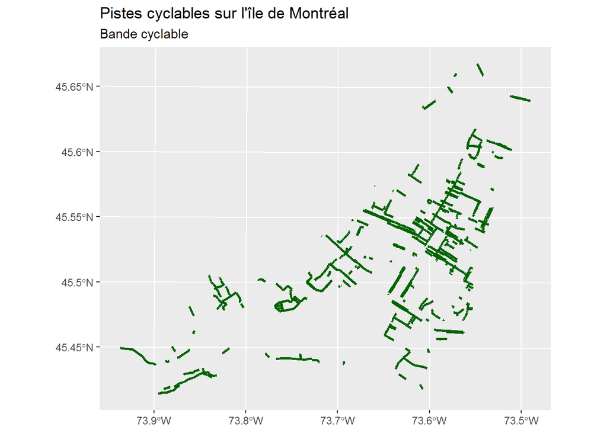

Bandes cyclables sur l’île de Montréal

```r
ggplot()+
  geom_sf(data = Bande,  size = 1, color = "darkgreen")+
  ggtitle("Pistes cyclables sur l'île de Montréal", subtitle = "Bande cyclable")
```

Nous voulons maintenant représenter les six types de voie cyclable par six couleurs différentes. Créons d’abord un vecteur de six couleurs, ce qu’on appelle une palette de couleurs.

```r
couleurs_voie<-c("darkgreen", "turquoise", "yellow","darkblue","violet","orange")
```

Nous pouvons demander à `ggplot` d’utiliser ces couleurs pour illustrer les différents types de voie cyclable (Fig @ref(fig:plot-voie5)).

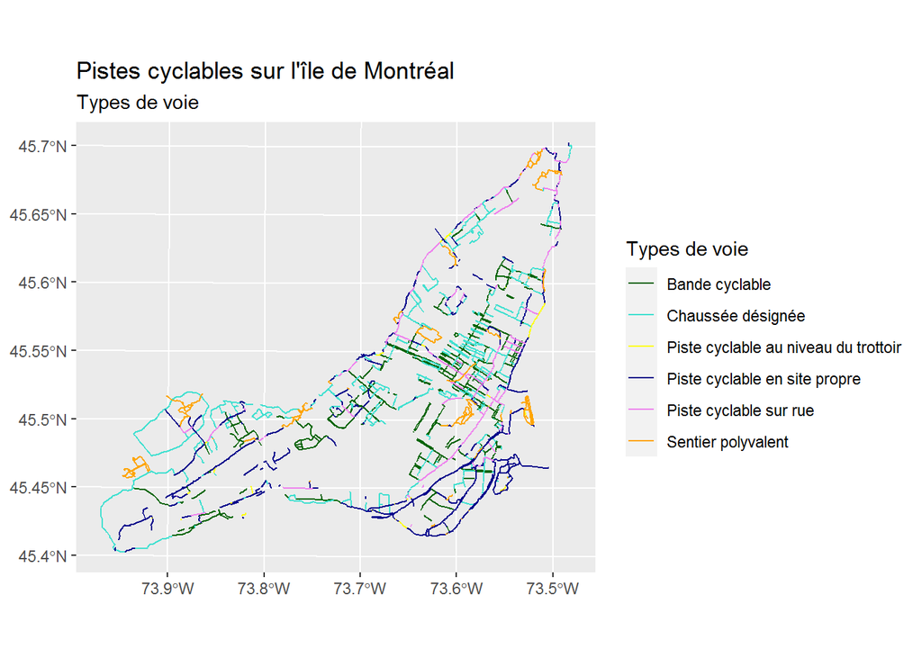

Types de voie cyclable sur l’île de Montréal

```r
ggplot()+
  geom_sf(data = pistes_cyclables,  aes(color = TYPE_VOIE))+
  scale_color_manual(values = couleurs_voie)+
  labs(color = 'Types de voie')+
  ggtitle("Pistes cyclables sur l'île de Montréal", subtitle = "Types de voie")
```

La fonction `aes` décrit quelles variables dans les données (`data`) sont illustrées (dans notre exemple, ce sont `TYPE_VOIE`) et par quelles caractéristiques visuelles[^4]. On nomme ces caractéristiques visuelles les “esthétiques” (`aes` pour “aesthetic” en anglais). Dans le présent exemple, nous nous préoccupons seulement de la couleur des données vectorielles, mais nous aurions pu aussi changer leur taille, le type de lignes, ou la forme des symboles (si la géométrie des données étaient de type point).

La fonction `scale_color_manual` permet de spécifier nos propres couleurs, sans quoi ce seront les couleurs par défaut qui seront utilisées[^5].

Finalement, la fonction `labs` permet d’assigner un titre à la légende, sans quoi c’est le nom de la variable, telle que nous l’avons définie dans `R` qui sera affichée, ici, `TYPE_VOIE`.

Nous pouvons aussi demander à `ggplot` de représenter les types de voie cyclable en utilisant différentes tailles de trait. De la même façon que précédemment, nous créons un vecteur de six tailles.

```r
tailles_voie<-c(1,1.2,1.5,1.7,2,2.2)
```

Puis représentatons les types de voie cyclable (Fig @ref(fig:plot-voie7)).

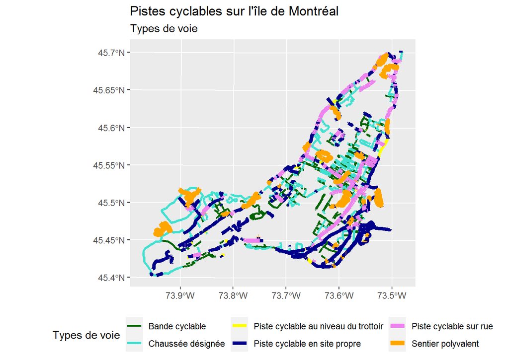

Types de voie cyclable sur l’île de Montréal (couleur et taille des traits)

```r
ggplot()+
  geom_sf(data = pistes_cyclables,  aes(color = TYPE_VOIE, size = TYPE_VOIE))+
  scale_color_manual(values = couleurs_voie)+
  labs(color = 'Types de voie')+
  scale_size_manual(values = tailles_voie)+
  labs(size = 'Types de voie')+
  ggtitle("Pistes cyclables sur l'île de Montréal", subtitle = "Types de voie")+
  theme(legend.position = "bottom")
```

La légende tient compte à la fois de la couleur, et de la taille des traits. De plus, nous l’avons affichée au bas de la figure.

#### Visualiser plusieurs *shapefiles*

Nous allons maintenant représenter les données vectorielles `limites terrestres`, `pistes_cyclables` et `accidents_velo` au sein d’une même figure. Il s’agit d’utiliser la fonction `geom_sf` pour chaque couche de données et de les combiner en utilisant le `+`.

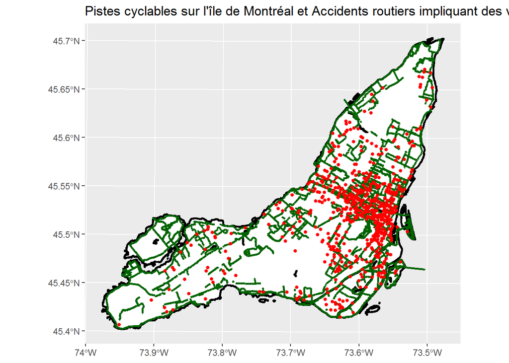

Pistes cyclables et position des accidents routiers impliquant des bicyclettes sur l’île de Montréal

```r
ggplot()+
  geom_sf(data = limites_terrestres, size = 1, color = "black", fill = "white")+
  geom_sf(data = pistes_cyclables, size = 1, color = "darkgreen")+
  geom_sf(data = accidents_velo, pch = 19, cex = 1.25, color = "red")+
  ggtitle("Pistes cyclables sur l'île de Montréal et Accidents routiers impliquant des vélos")
```

Nous pouvons créer une carte plus précise qui spécifie les types de voie cyclable et ajouter une légende.

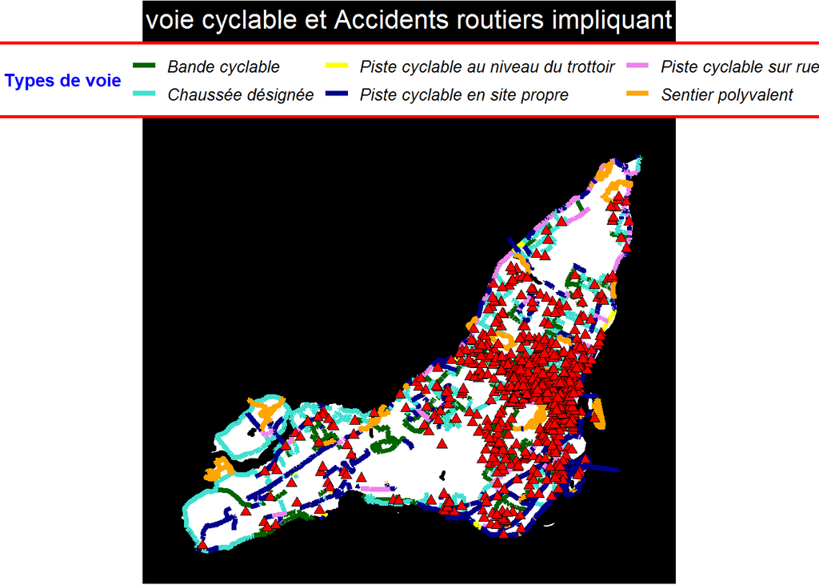

Types de voie cyclable et position des accidents routiers impliquant des bicyclettes sur l’île de Montréal.

```r
ggplot()+
  geom_sf(data = limites_terrestres, size = 1, color = "black", fill = "white")+
  geom_sf(data = pistes_cyclables, size = 1.5, aes(color = TYPE_VOIE),  show.legend = "line")+
  scale_color_manual(values = couleurs_voie,name = "Types de voie")+
  geom_sf(data = accidents_velo, pch = 24, cex = 2, fill = "red", color = "black")+
  ggtitle("Types de voie cyclable et Accidents routiers impliquant des vélos")+
theme(
      #Caractéristiques de la figure elle-même
      panel.background = element_rect(fill = "black"), #le dessous de la carte
      plot.background = element_rect(fill = "black"),  #le contour de la carte
      panel.grid.major = element_blank(),              #retirer la grille cartésienne
      axis.ticks = element_blank(),                    #retirer les traits sur les axes
      axis.text.x = element_blank(),                   #retirer les traits les noms ou les numéros de ces traits
      axis.text.y = element_blank(),
      plot.title = element_text(colour = "white", size = 16, hjust = 0.5), #Centrer le titre de la carte
      #Caractéristiques de la légende
      legend.position = "top",                         #position de la légende
      legend.title = element_text(colour="blue", size = 11, face = "bold"), #titre de la légende
      legend.text = element_text(size = 10, face = "italic"),               #texte des éléments de la légende
      legend.background = element_rect(fill = "white", size = 1, linetype = "solid", colour = "red"), #rectangle autour de la légende
      legend.key = element_rect(fill = "white")        #couleur blanche sous les éléments de la légende
)
```

La fonction `theme()` permet d’ajuster l’apparence de la carte (couleur du fond, couleur, taille et position du titre, format de la légende, etc.). Le chapitre [Modify components of theme](https://ggplot2.tidyverse.org/reference/theme.html) [@Wickham_ggplot2_2016] énumère l’ensemble des paramètres pouvant être modifiés pour changer l’apparence d’une carte.

### Reprojection de données vectorielles sous R

Dans cette section vous apprendrez à manipuler le système de coordonnées de référence de données vectorielles. Nous avons vu en début de leçon que les données utilisées sont dans la projection de Mercator transverse (`tmerc`) et utilisent le Système de référence géodésique nord-américan de 1983 (`NAD83`). Par exemple, pour connaître le SCR des données `limites_terrestres`, nous avions fait:

```r
st_crs(limites_terrestres)
```

```
## Coordinate Reference System:
##   User input: NAD83 / MTM zone 8
##   wkt:
## PROJCRS["NAD83 / MTM zone 8",
##     BASEGEOGCRS["NAD83",
##         DATUM["North American Datum 1983",
##             ELLIPSOID["GRS 1980",6378137,298.257222101,
##                 LENGTHUNIT["metre",1]]],
##         PRIMEM["Greenwich",0,
##             ANGLEUNIT["degree",0.0174532925199433]],
##         ID["EPSG",4269]],
##     CONVERSION["MTM zone 8",
##         METHOD["Transverse Mercator",
##             ID["EPSG",9807]],
##         PARAMETER["Latitude of natural origin",0,
##             ANGLEUNIT["degree",0.0174532925199433],
##             ID["EPSG",8801]],
##         PARAMETER["Longitude of natural origin",-73.5,
##             ANGLEUNIT["degree",0.0174532925199433],
##             ID["EPSG",8802]],
##         PARAMETER["Scale factor at natural origin",0.9999,
##             SCALEUNIT["unity",1],
##             ID["EPSG",8805]],
##         PARAMETER["False easting",304800,
##             LENGTHUNIT["metre",1],
##             ID["EPSG",8806]],
##         PARAMETER["False northing",0,
##             LENGTHUNIT["metre",1],
##             ID["EPSG",8807]]],
##     CS[Cartesian,2],
##         AXIS["easting (E(X))",east,
##             ORDER[1],
##             LENGTHUNIT["metre",1]],
##         AXIS["northing (N(Y))",north,
##             ORDER[2],
##             LENGTHUNIT["metre",1]],
##     USAGE[
##         SCOPE["unknown"],
##         AREA["Canada - Quebec and Ontario - 75Â°W to 72Â°W"],
##         BBOX[44.98,-75,62.53,-72]],
##     ID["EPSG",32188]]
```

Nous allons maintenant transformer le SCR vers la projection de Robinson (`robin`) et le Système géodésique mondial de 1984 (`WGS84`). Pour se faire nous utilisons la fonction `st_transform` de la librarie `st`.

```r
limites_terrestres_rob <- st_transform(limites_terrestres,
    CRS("+proj=robin +datum=WGS84"))
```

Comparons les données transformées avec les données initiales. Pour se faire, nous voulons représenter les deux cartes une au-dessous de l’autre. La librarie `ggpubr` permet de créer facilement des figures avec des panneaux multiples. Installez la librarie si ce n’est pas déjà fait, et chargez-là dans votre session de travail.

```r
library(ggpubr)
```

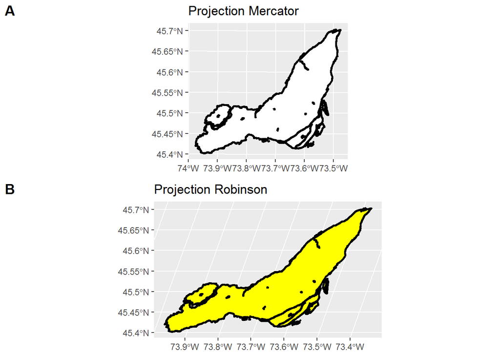

Limites terrestres de l’île de Montréal selon les projections Mercartor (A) et Robinson (B)

```r
carte1<-ggplot()+
  geom_sf(data = limites_terrestres, size = 1, color = "black", fill = "white") +
  ggtitle("Projection Mercator")
carte2<-ggplot()+
  geom_sf(data = limites_terrestres_rob, size = 1, color = "black", fill = "yellow") +
  ggtitle("Projection Robinson")
figure <- ggarrange(carte1, carte2, labels = c("A","B"),ncol = 1, nrow = 2)
figure
```

```r
chemin<-"D:/votrechemin/SCI1031/Module4/Donnees/"
nom_du_fichier<- paste(chemin, "/Montreal_Velo/terre/terre_rob_shp.shp", sep = "")
st_read(limites_terrestres_rob,nom_du_fichier)
```

### Lire une géodatabase et explorer ses couches

Dans cette section, nous allons explorer les données vectorielles d’une géodatabase du Ministère de l’Éducation et de l’Enseignement supérieur du Québec (MEES).

#### Importer les données

Téléchargez les [données du MEES](https://github.com/sci1031/sci1031/tree/master/Module4/data/Donnees_Ouvertes_MEES.zip). Sauvegardez le dossier compressé (`zip`) dans votre répertoire de travail `Donnees` pour ce module, et dézippez-le. Le dossier Donnees_Ouvertes_MEES comprend un seul sous-dossier, Donnees_Ouvertes_MEES.gdb, c’est la geodatabase qui elle contient de multiples fichiers de formats différents.

#### Lire les données

La géodatabase Donnees_Ouvertes_MEES.gdb que vous venez de télécharger contient plusieurs couches de données vectorielles (*layers*) sur les établissements d’enseignement au Québec.

Pour lire et explorer une géodatabase, on continue à utiliser la libraries `sf`. Chaque couche peut être lue individuellement en utilisant la fonction `st_read()`: `st_read(“nom_de_la_geodatabase.gdb”, layer = “nom_de_la_couche”). Il est donc nécessaire de connaître d’abord les noms donnés aux couches composants la géodatabase - information qui nous est, pour l’instant, inconnue.

```r
chemin<-"D:/votrechemin/SCI1031/Module4/Donnees/"
nom_du_fichier <- paste(chemin, "/Donnees_Ouvertes_MEES/Donnees_Ouvertes_MEES.gdb", sep = "")
couches_mees <- st_layers(nom_du_fichier)
```

[output not shown]

#### Visualisation

[^1]: L’ensemble du matériel disponible dans ce module est adapté du cours *Introduction to Geospatial Raster and Vector Data with R* [@Data_Carpentry_IntroGeospatial] de l’organisme [Data Carpentry](https://datacarpentry.org/). Data Carpentry développe et offre des formations variées et spécialisées sur le traitement et l’analyse de données. Ses formations s’adressent surtout aux chercheuses et chercheurs scientifiques, mais peuvent être consultées par quiconque car leur matériel est libre d’accès. N’hésitez donc pas à y jeter un coup d’œil.
[^2]: Pour plus d’information sur la fonction `geom_sf`, consultez le chapitre [Visualise sf objects](https://ggplot2.tidyverse.org/reference/ggsf.html) [@Wickham_ggplot2_2016]
[^3]: Ville de Montréal. Aménagements cyclables. Repéré le 19 mars 2020
[^4]: Pour plus d’information sur la fonction `aes`, consultez le chapitre [Construct aesthetic mappings](https://ggplot2.tidyverse.org/reference/aes.html) [@Wickham_ggplot2_2016]
[^5]: Pour plus d’information sur la fonction `scale_colour_manual`, consultez le chapitre [Create your own discrete scale](https://ggplot2.tidyverse.org/reference/scale_manual.html) [@Wickham_ggplot2_2016]